# Nature Climate Change paper results

### below 50th

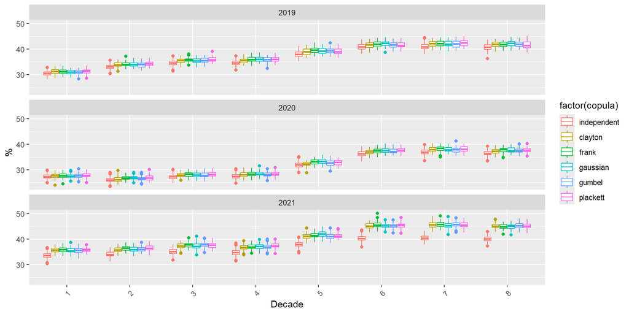

### below 75th

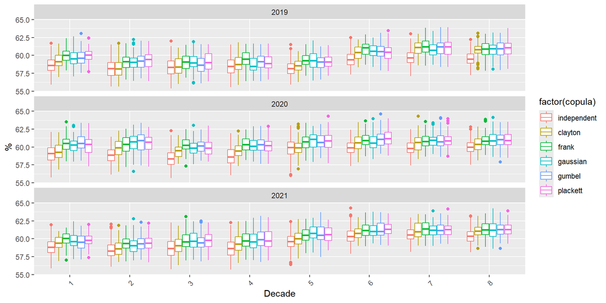

### below 90th

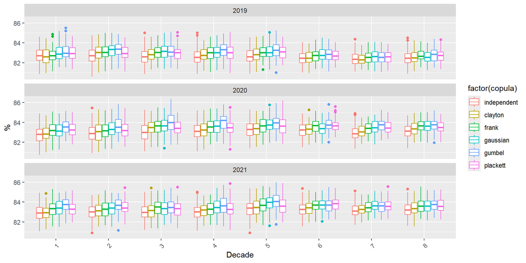

### % diff. trips catch above 50th [(ind-corr)/corr]*100

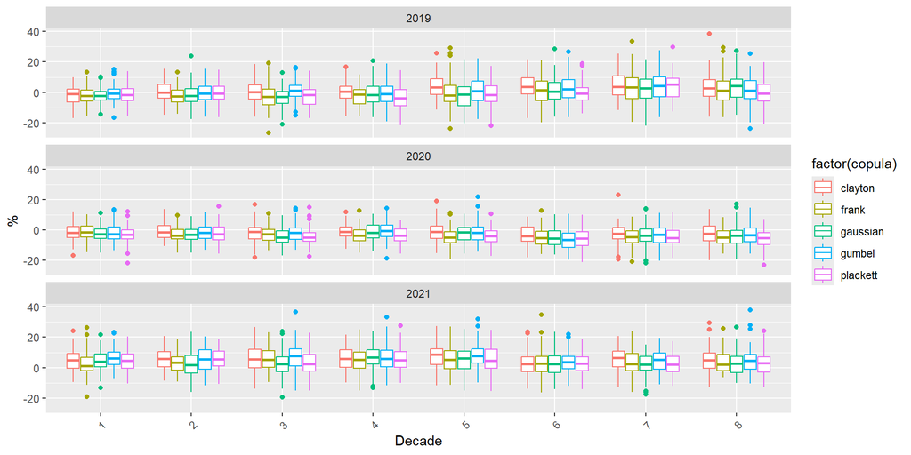

### % diff. trips catch above 75th [(ind-corr)/corr]*100

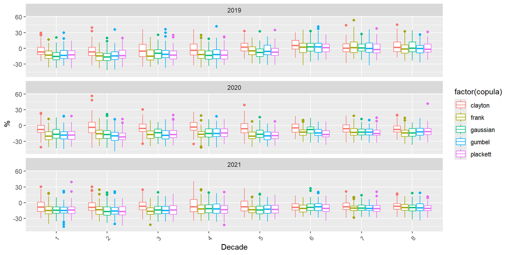

### % diff. trips catch above 90th [(ind-corr)/corr]*100

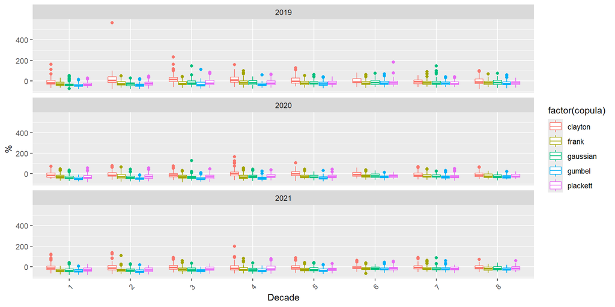

### % diff. trips catch below 35th [(ind-corr)/corr]*100

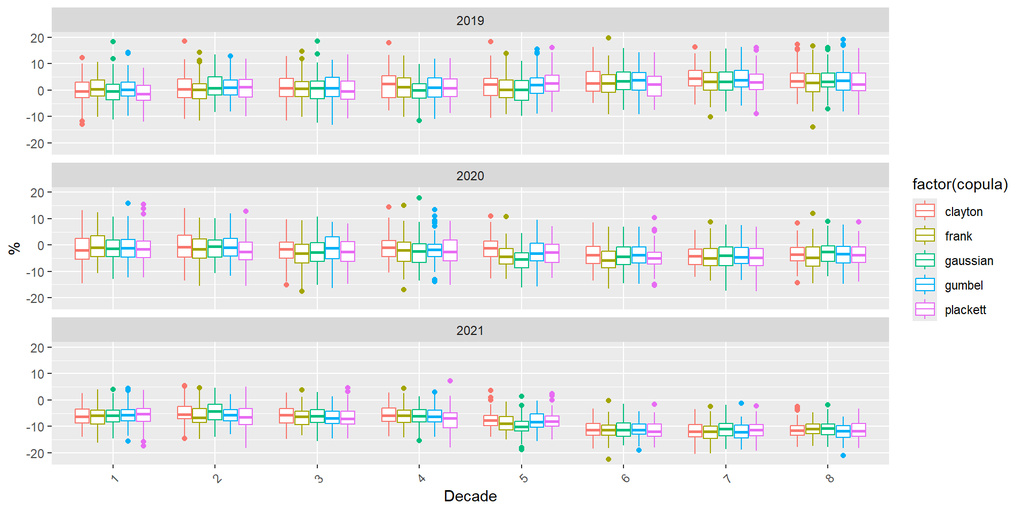

### % diff. trips catch below 50th [(ind-corr)/corr]*100

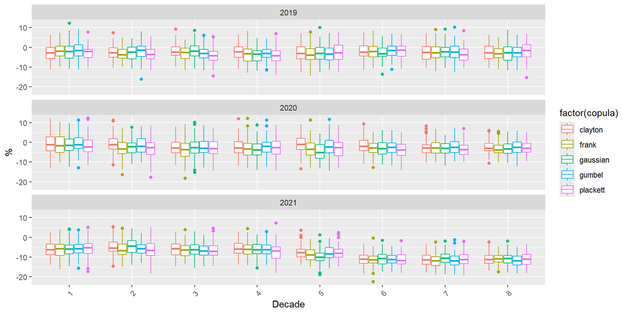

### % diff. trips catch below 75th [(ind-corr)/corr]*100

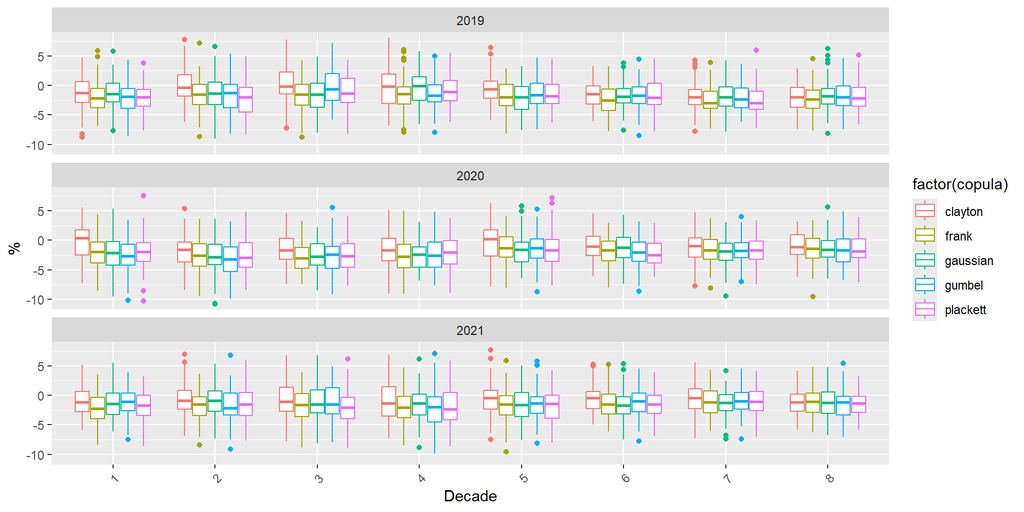

## Coastwide decadal projections - catch outcomes at the choice occasion level

Projected catch-per-trip data from 2025-09-18.

### cod catch per choice occasion

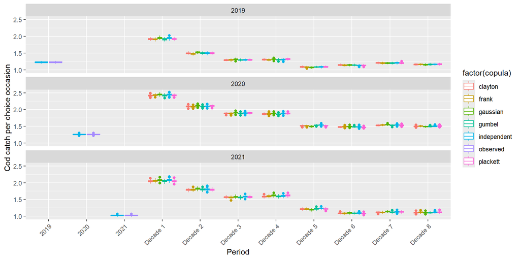

### cod keep per choice occasion

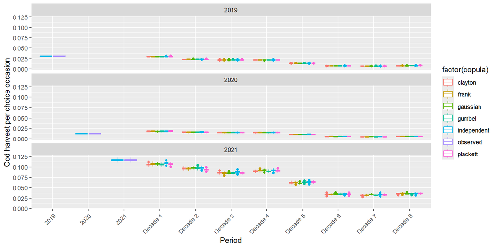

### cod release per choice occasion

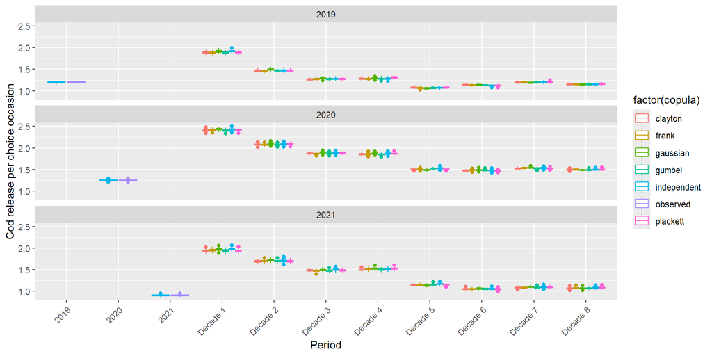

### haddock catch per choice occasion

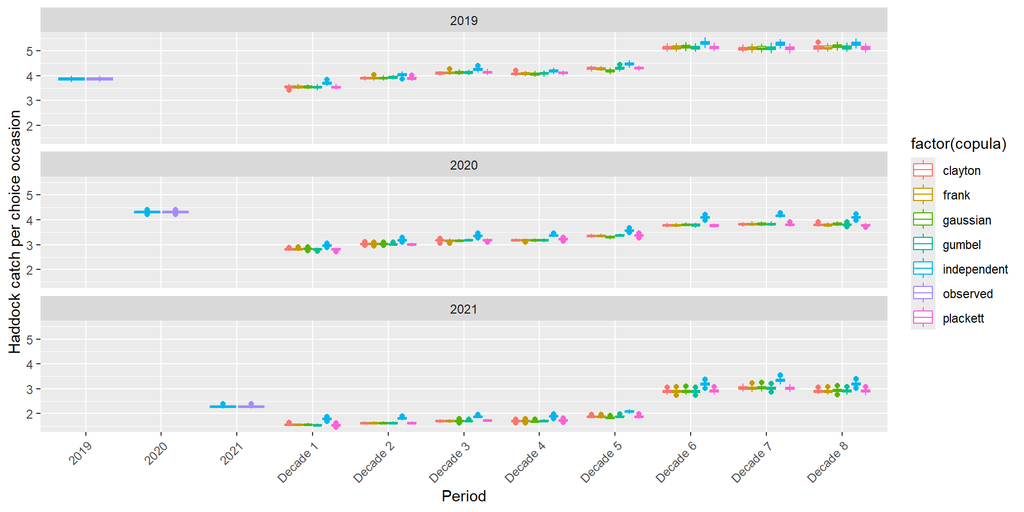

### haddock keep per choice occasion

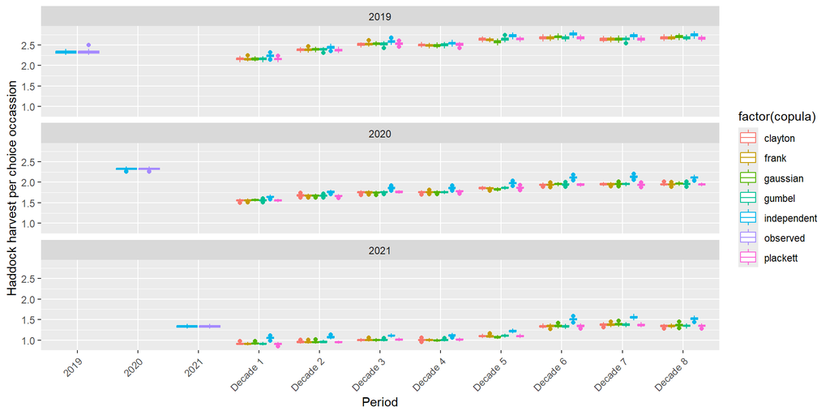

### haddock release per choice occasion

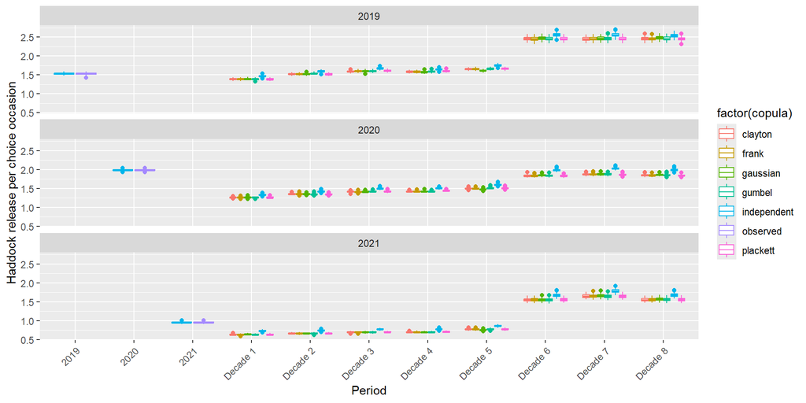

### cod keep per choice occasion

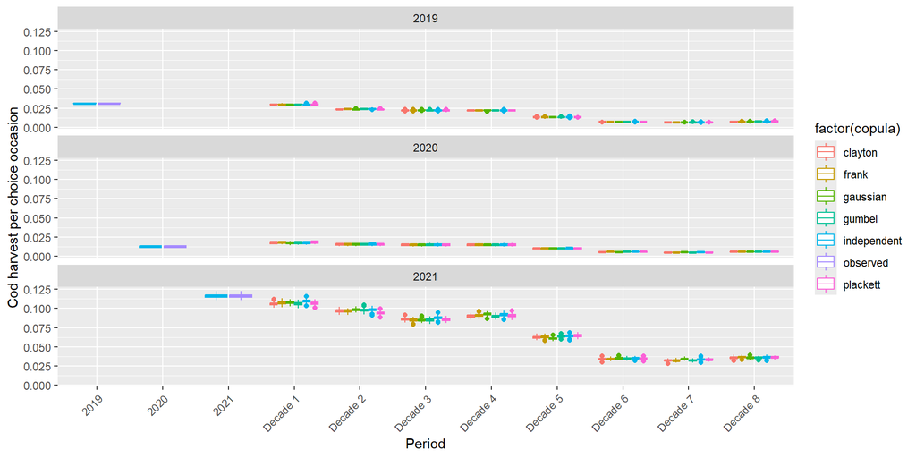

### cod release per choice occasion

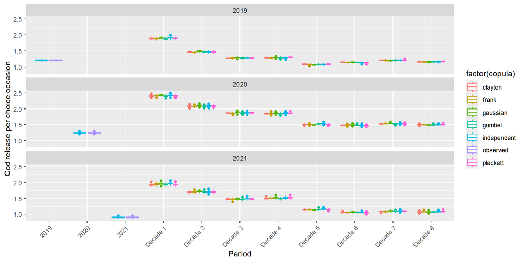

### haddock catch per choice occasion

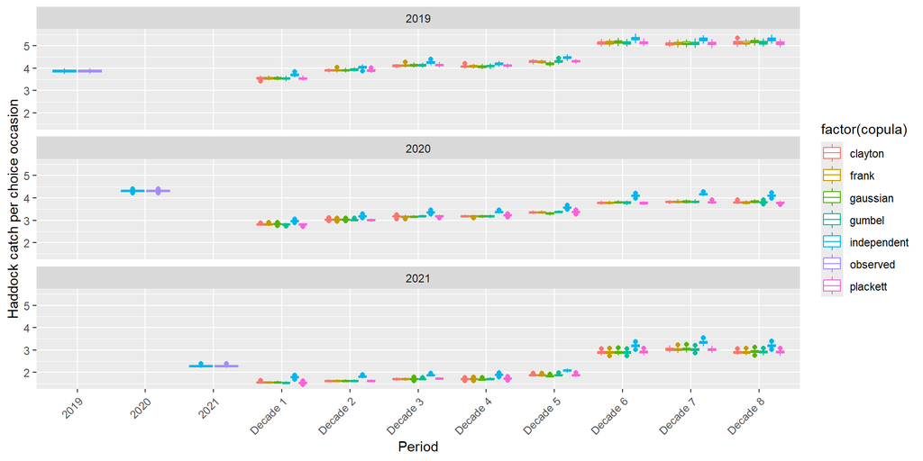

### haddock keep per choice occasion

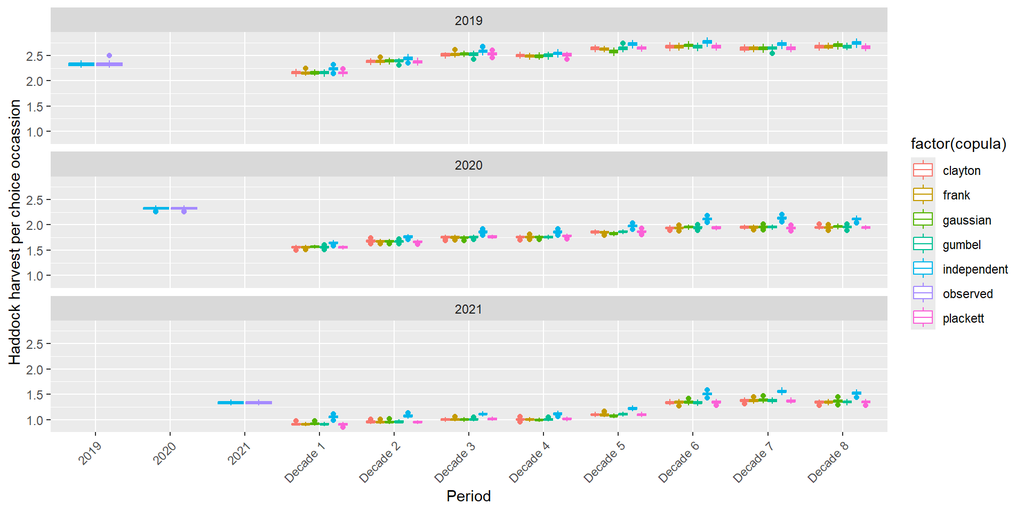

## Coastwide decadal projections by month- catch outcomes at the choice occasion level

Projected catch-per-trip data from 2025-09-18.

### cod catch per choice occasion by month and baseline year

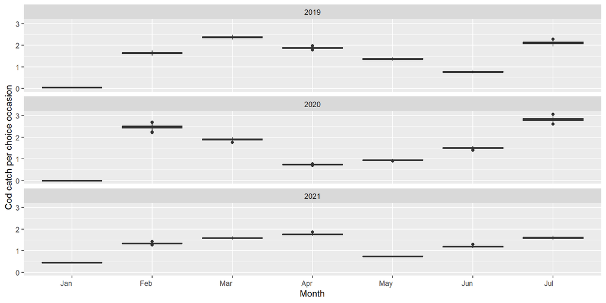

### haddock catch per choice occasion by month and baseline year

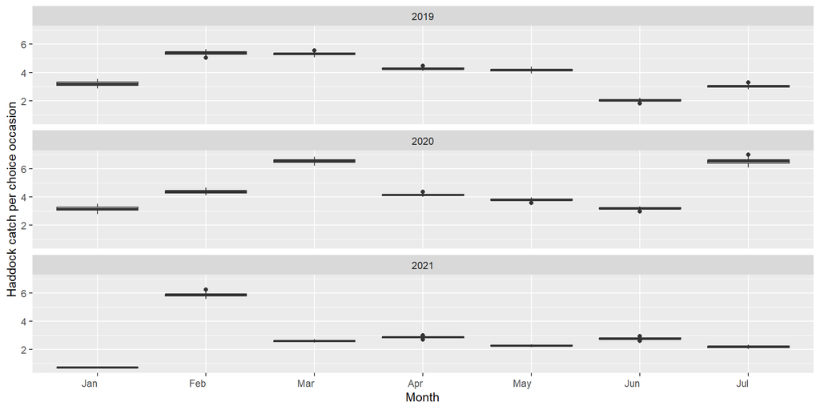

### cod catch per choice occasion by month - Decade 1 projections

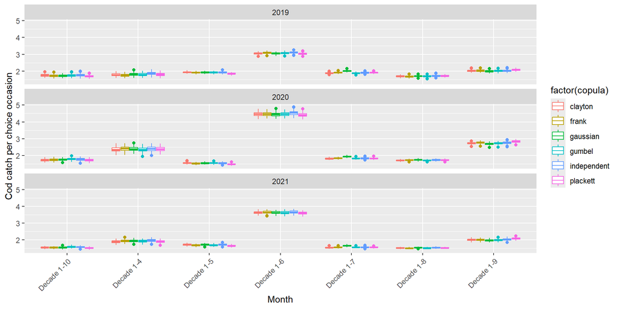

### haddock catch per choice occasion by month - Decade 1 projections

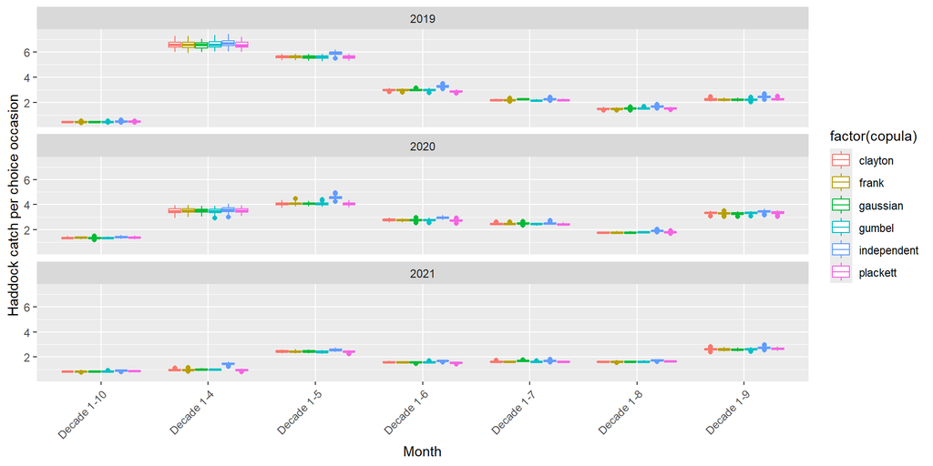

### cod catch per choice occasion by month - Decade 6 projections

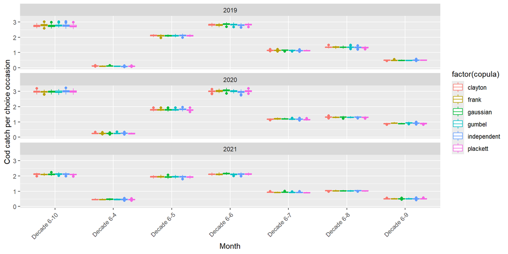

### haddock catch per choice occasion by month - Decade 6 projections

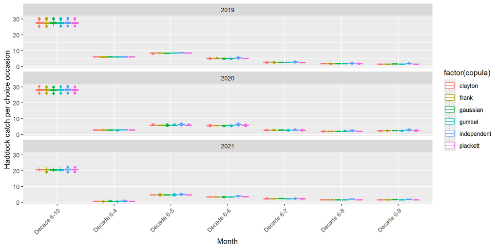

## Coastwide decadal projections - aggregate catch outcomes

### cod harvest

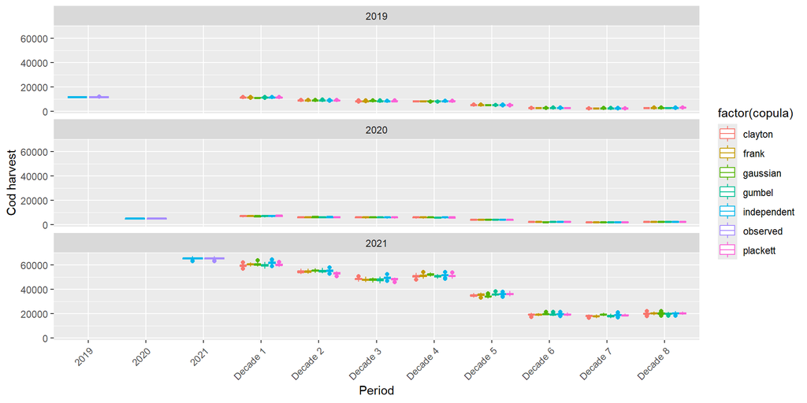

### haddock harvest

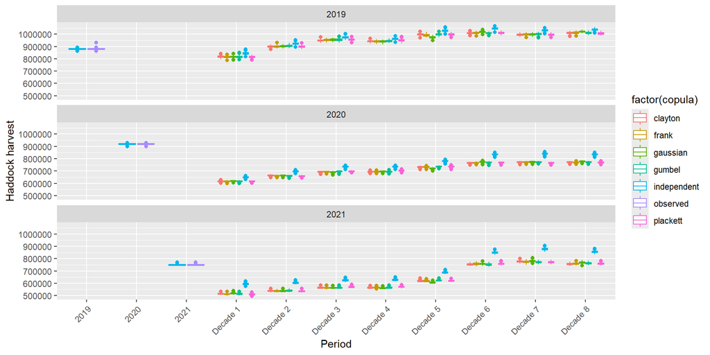

### cod total mortality

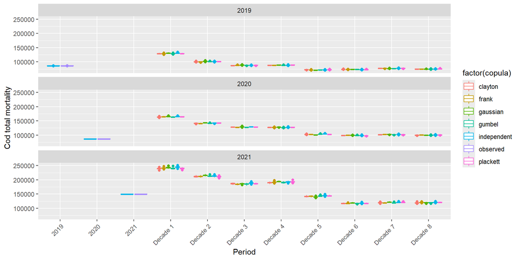

### haddock total mortality

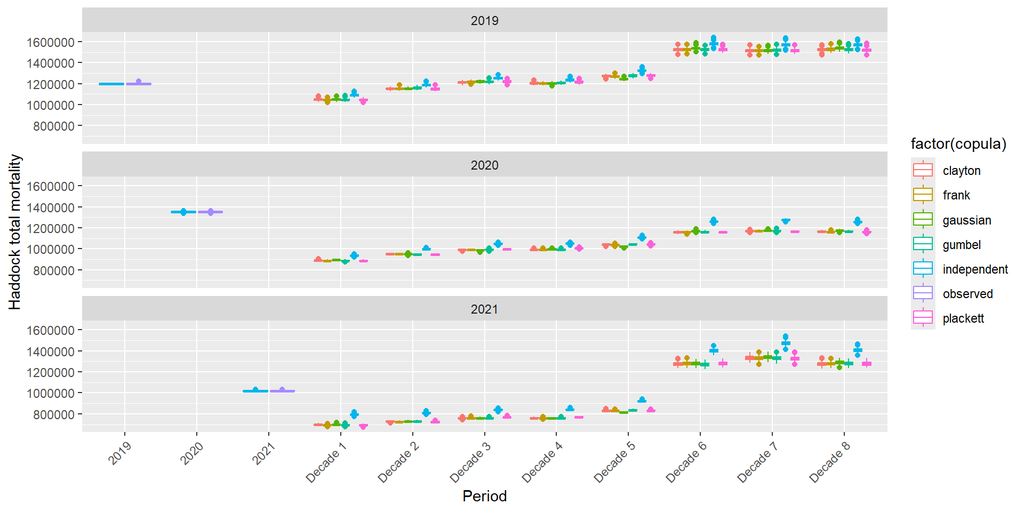

### cod plus haddock harvest

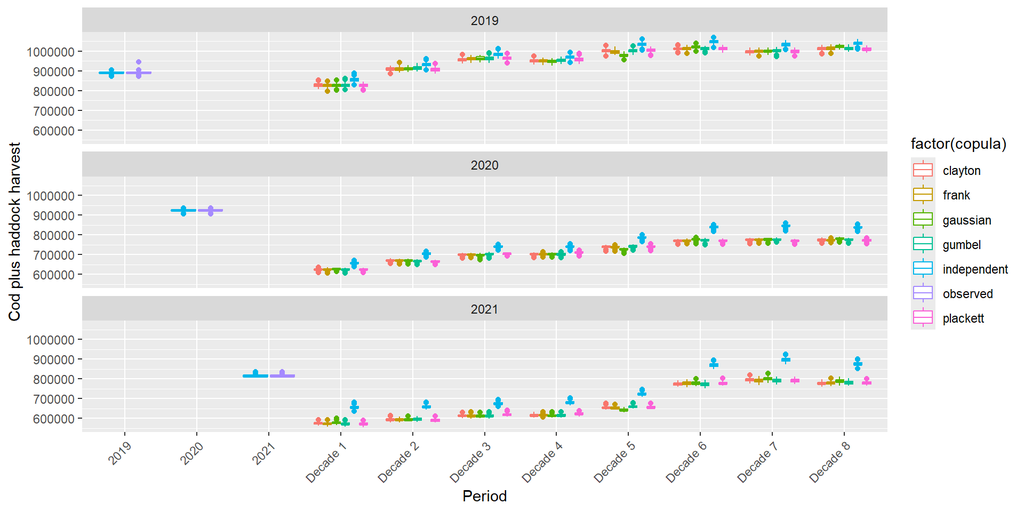

### cod catch

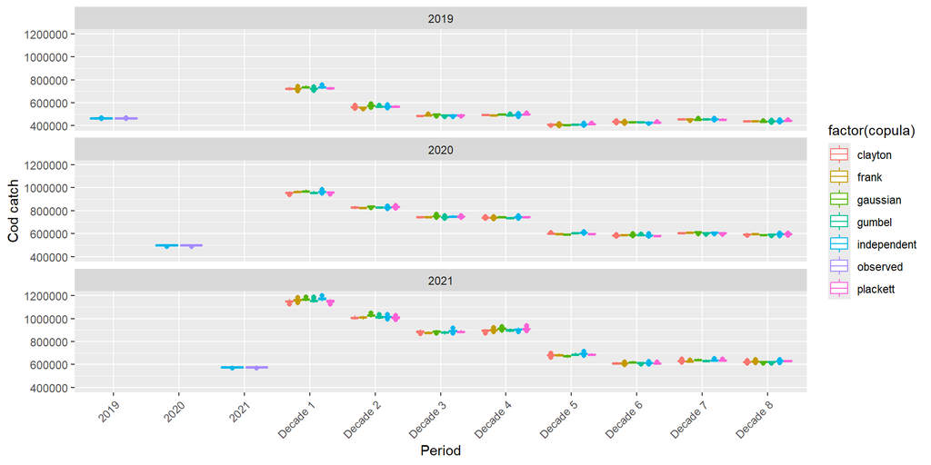

### haddock catch

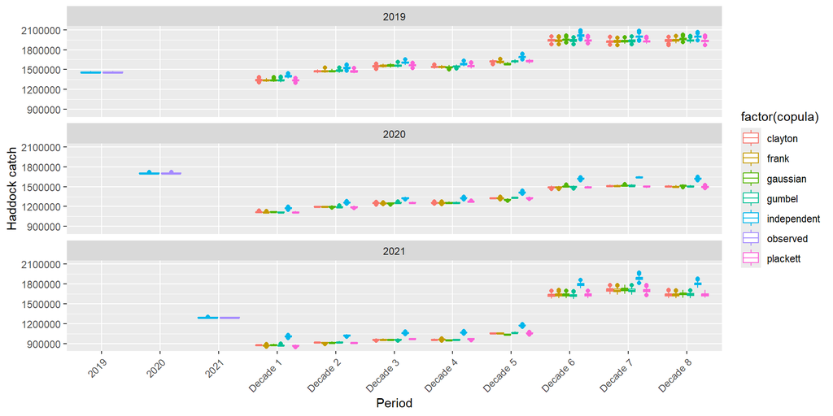

### cod plus haddock catch

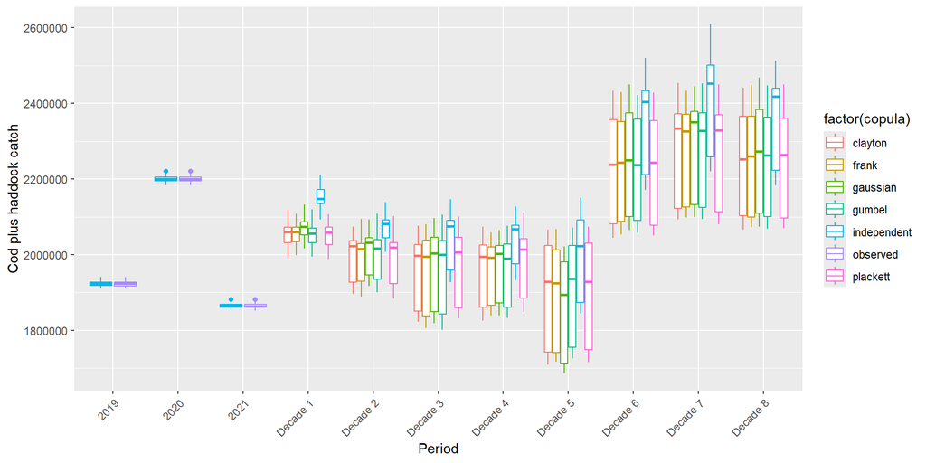

### Diff. total cod harvest

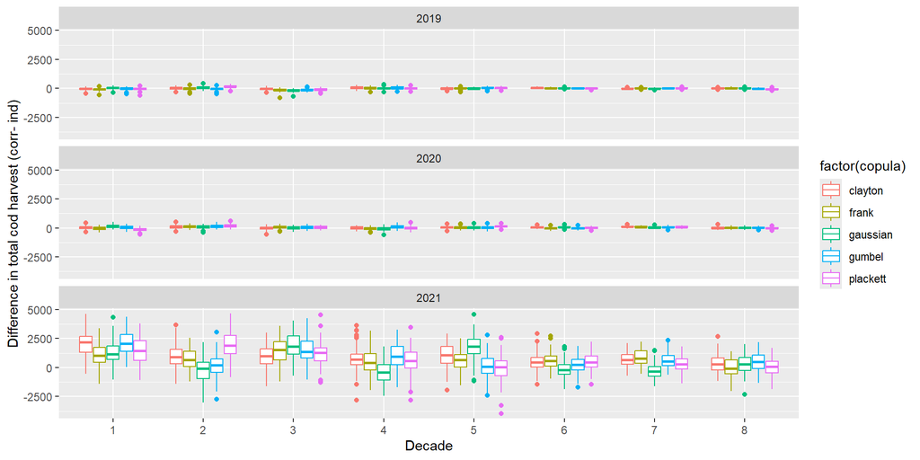

### Diff. total cod catch

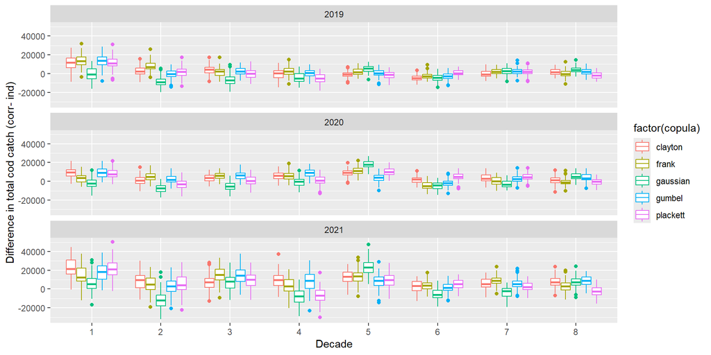

### Diff. total haddock harvest

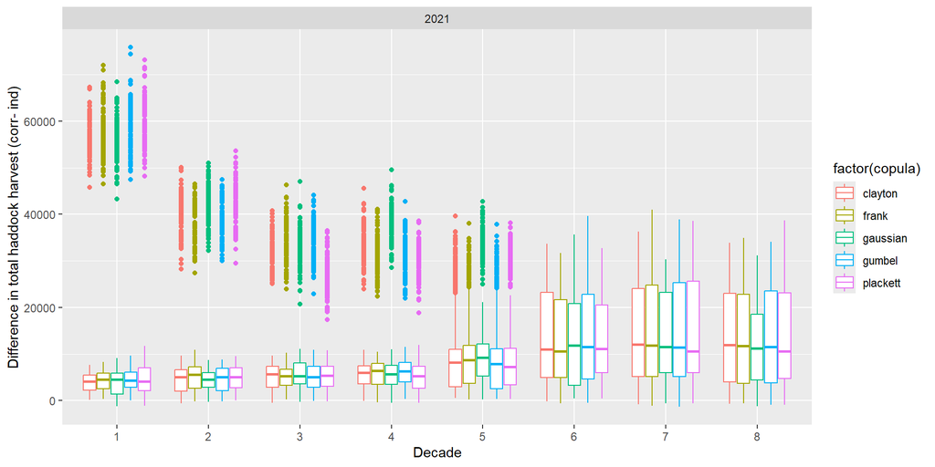

### Diff. total haddock catch

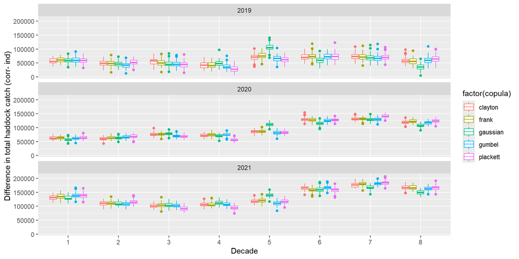

### Diff. total cod mortality

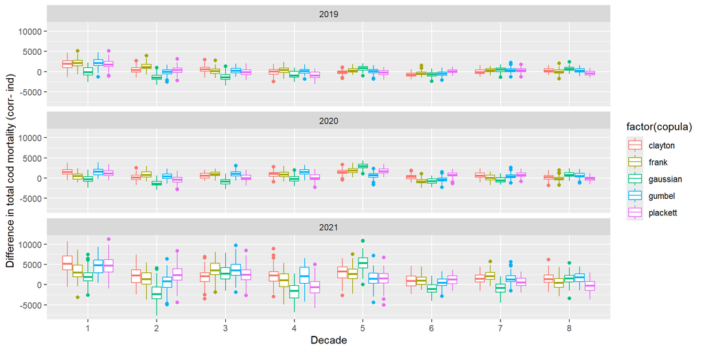

### Diff. total haddock mortality

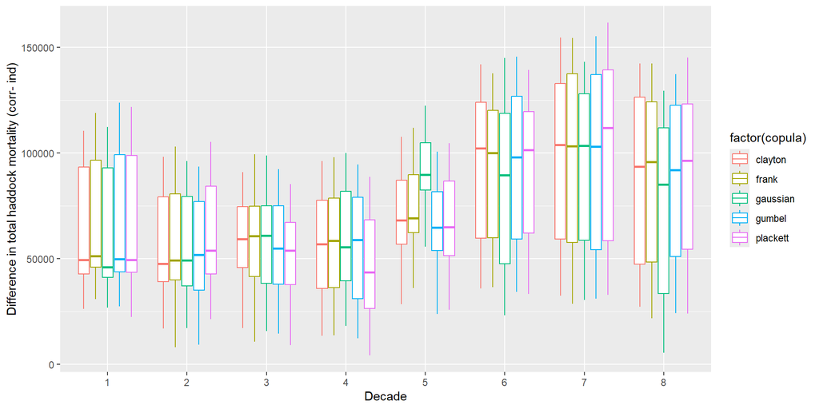

### Diff. total cod plus haddock harvest

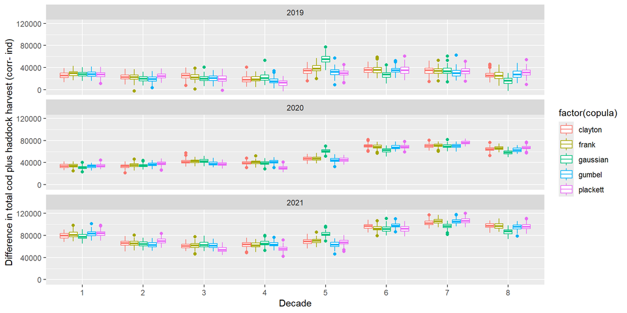

### Diff. total cod plus haddock catch

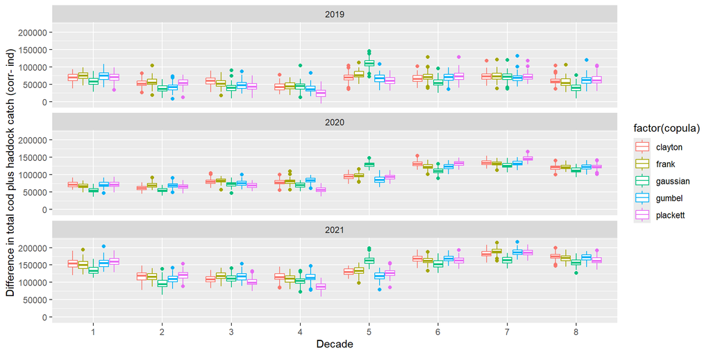

### Pct. diff. total cod harvest

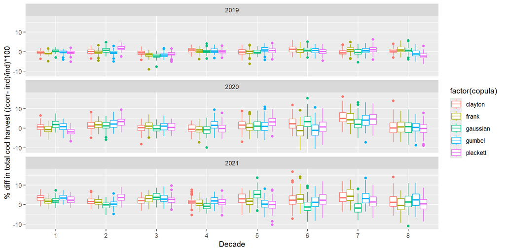

### Pct. diff. total cod catch

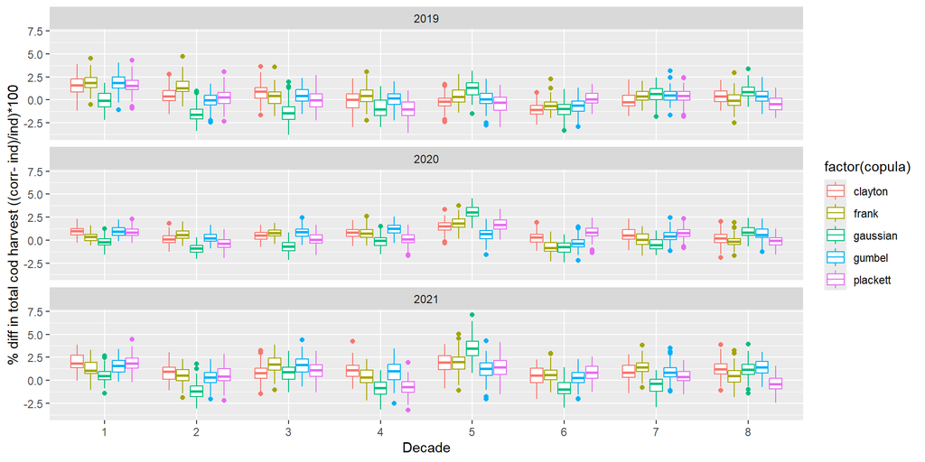

### Pct. diff. total haddock harvest

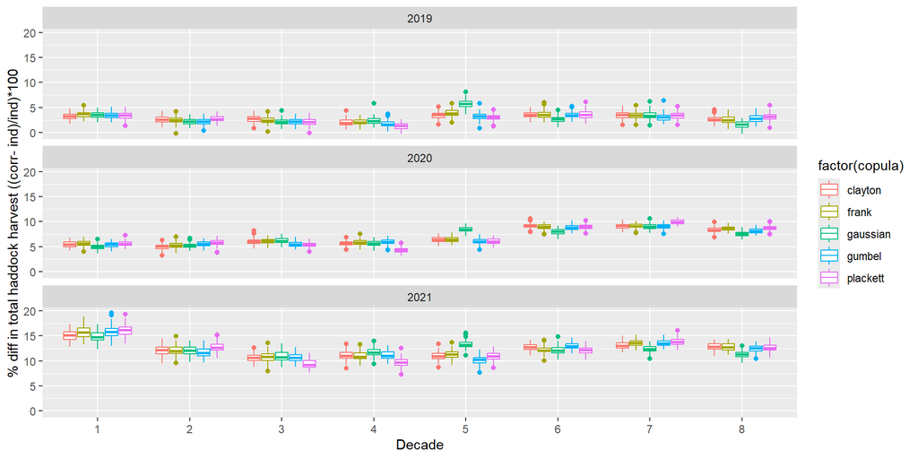

### Pct. diff. total haddock catch

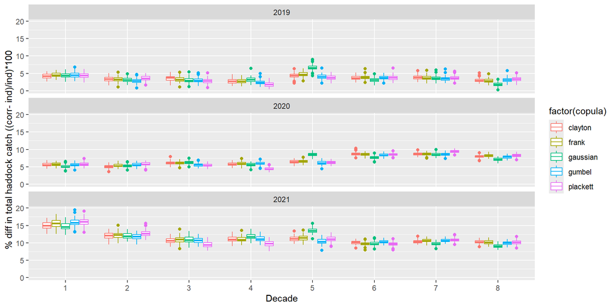

### Pct. diff. total cod mortality

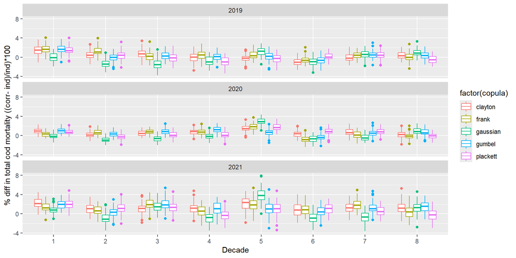

### Pct. diff. total haddock mortality

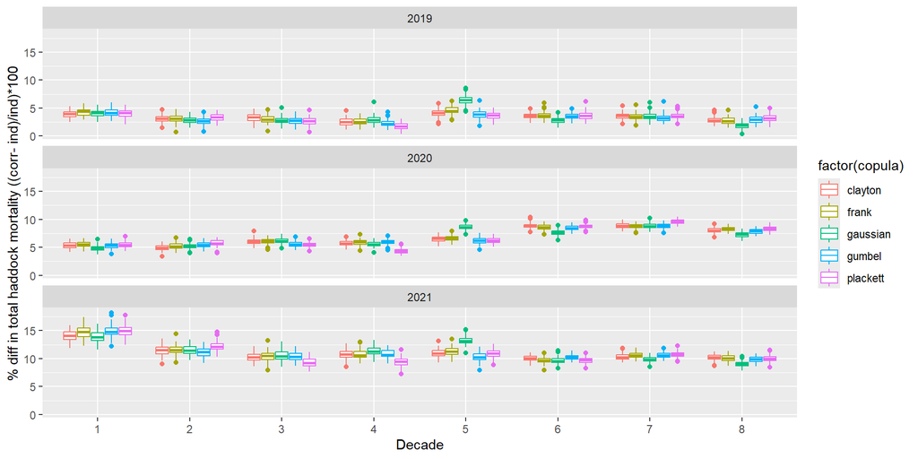

### Pct. diff. total cod plus haddock harvest

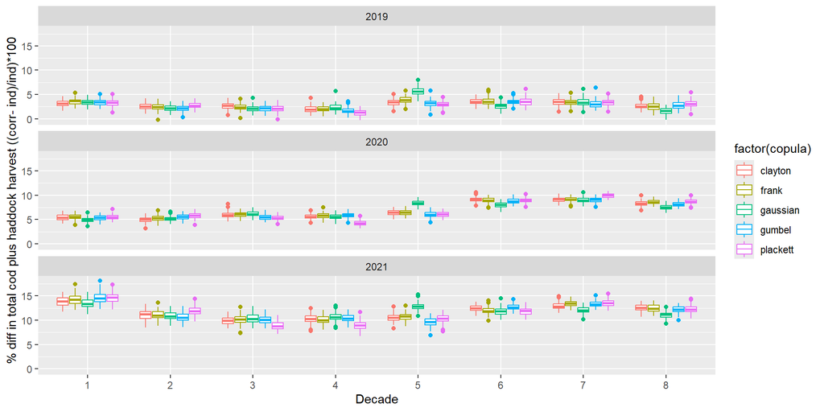

### Pct. diff. total cod plus haddock catch

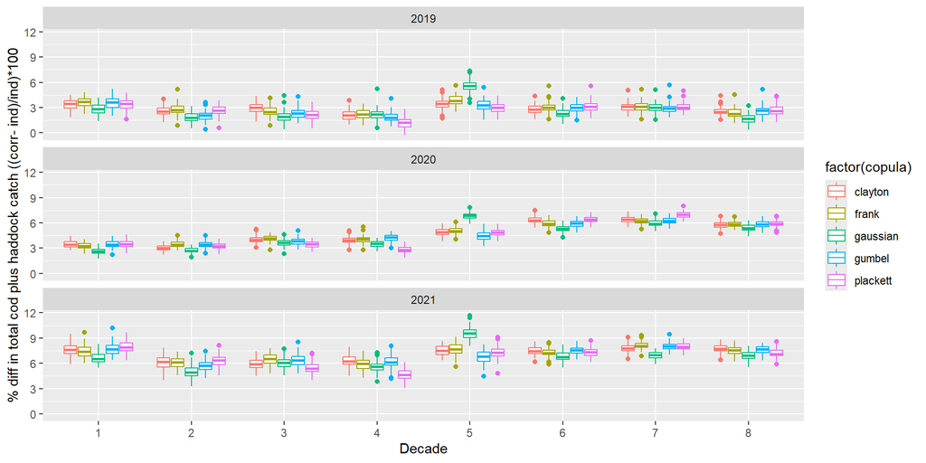

## Manuscript figures (base year = 2021)

### Absolute values

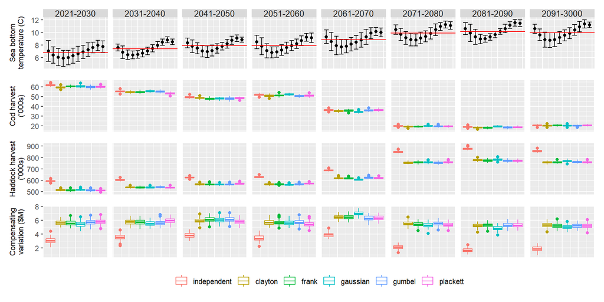

### Differences

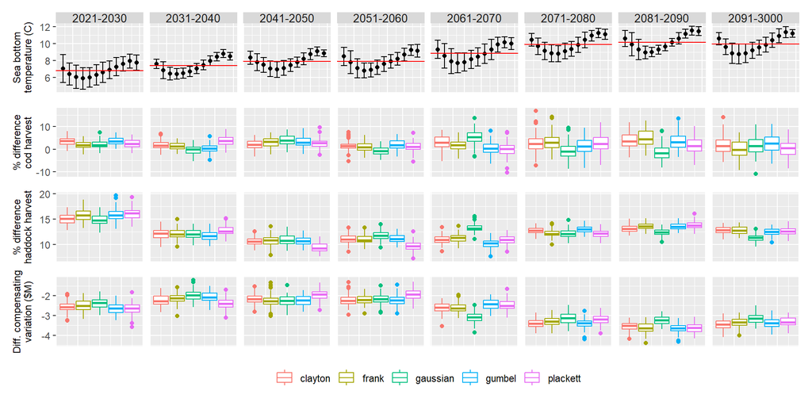

## Manuscript figures (base year = 2020)

### Absolute values

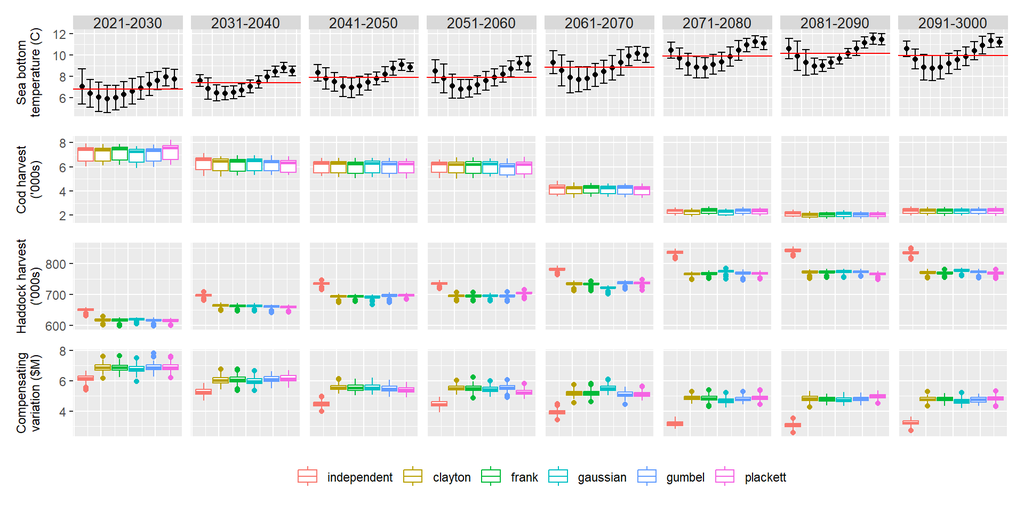

### Differences

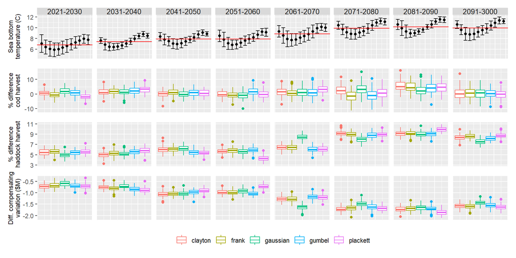

## Manuscript figures (base year = 2019)

### Absolute values

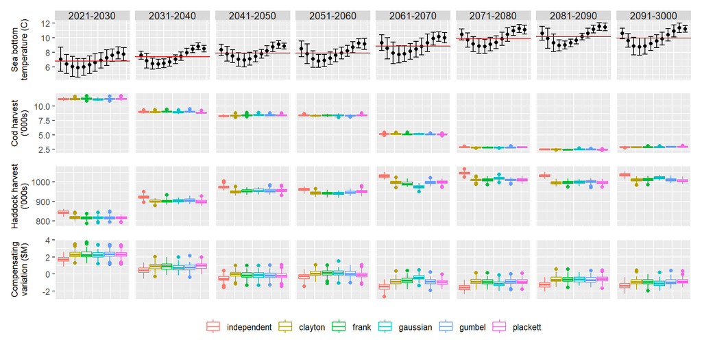

### Differences

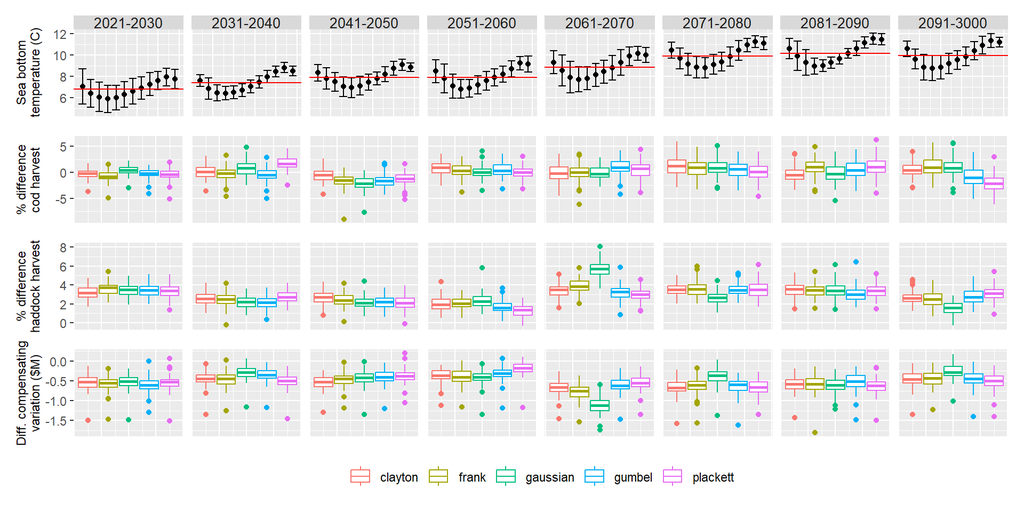

## Fishing-mode level decadal projections - welfare

Each tab contains different projected fishery outcomes across copula models for the case of dependence, independence, and the difference between dependence and independence. Projected catch-per-trip data from 2025-09-18.

### CV per trip

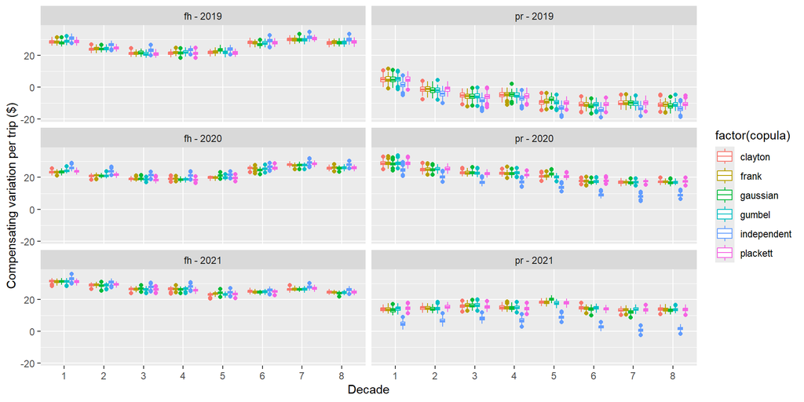

### Difference in CV per trip

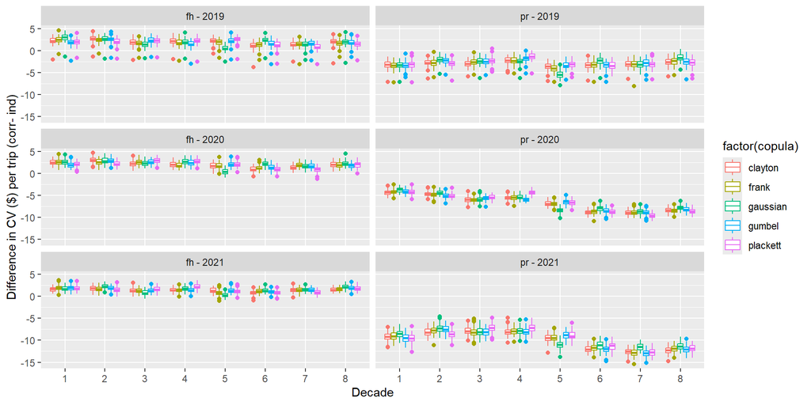

### CV per choice occasion

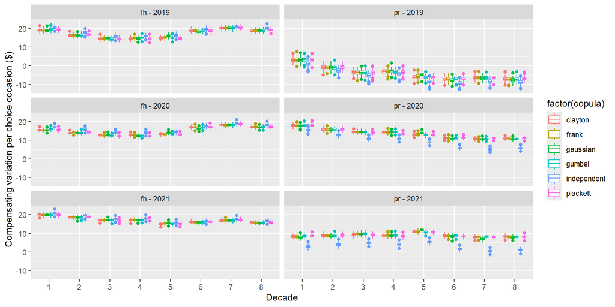

### Difference in CV per choice occasion

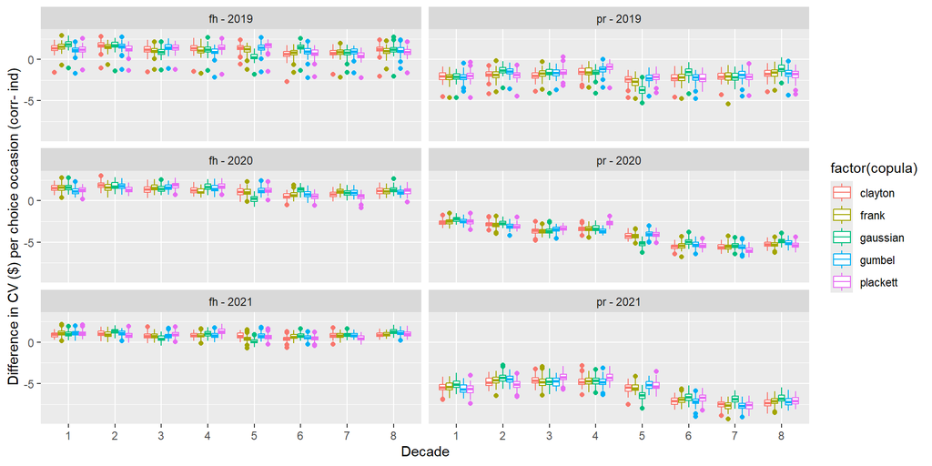

### Total CV

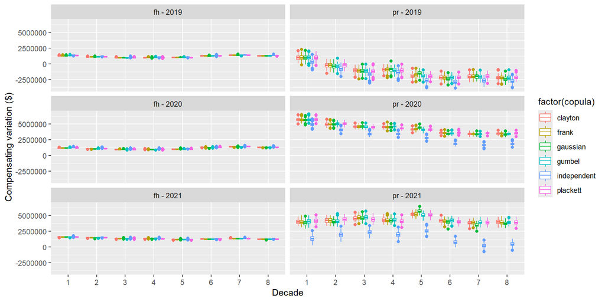

### Difference in total CV

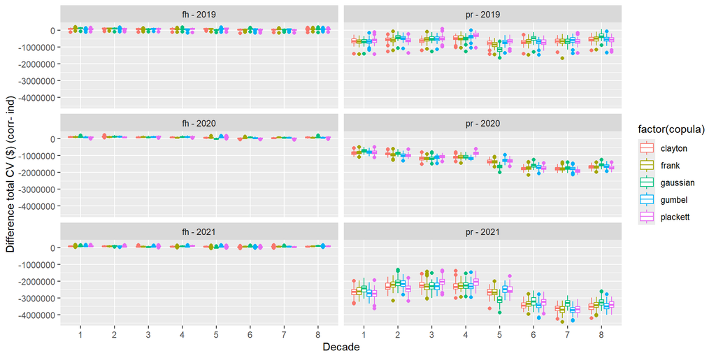

### Total directed trips

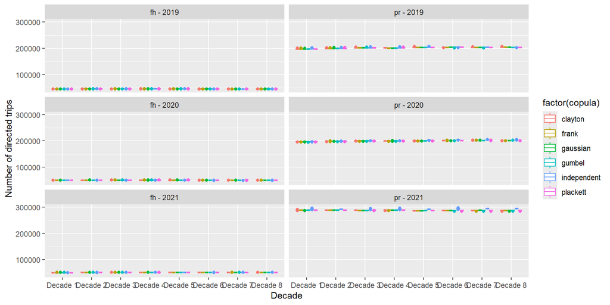

### Difference in total directed trips

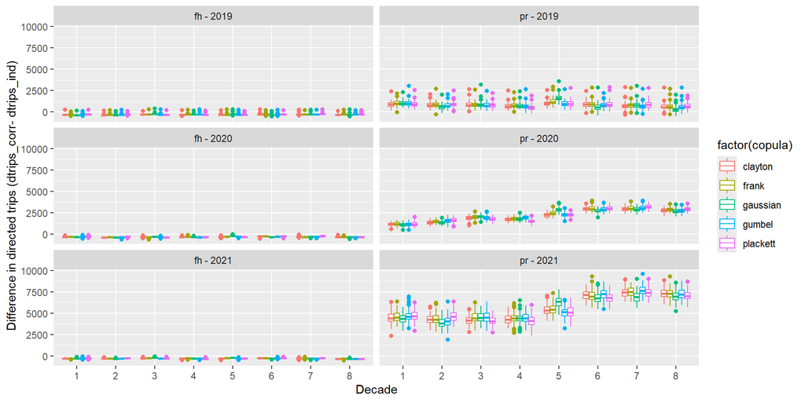

## Fishing-mode level decadal projections - catch outcomes at the trip level

Projected catch-per-trip data from 2025-09-18.

### cod catch per trip

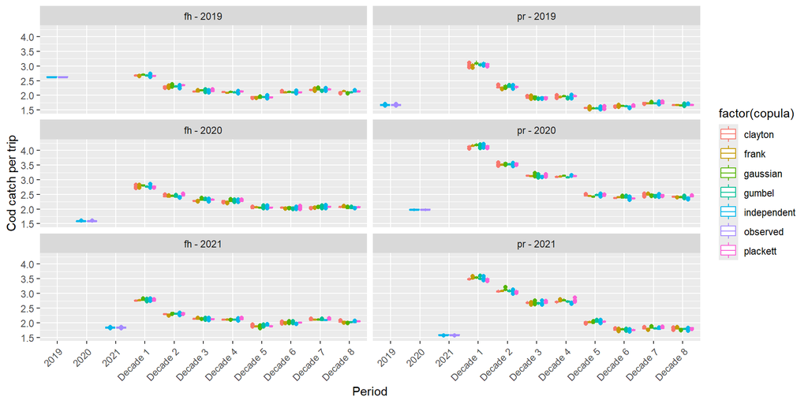